#### Find the Lowest-Forecast-RMSE Model Based on the Forecast Converted Back from the First Differences

In my final post, I plan to compared the undifferenced forecast RMSEs.

#### 1. Forecast RMSEs under Various Model Structures and Lags

1. The Forecast RMSEs when Employment 1st Diff and CPI 1st Diff as endogenous variables, without any exogenous variables.

```
No Season
              Lag1    Lag2    Lag3    Lag4    Lag5    Lag6    Lag7
Employment 4081.75 3670.71 3400.41 3393.01 3399.39 3446.28 3621.52
CPI          30.05   28.53   24.84   22.43   20.09   17.00   14.15
Sum        4111.80 3699.24 3425.25 3415.44 3419.48 3463.28 3635.67
              Lag8    Lag9   Lag10
Employment 4814.42 4949.59 4744.95
CPI           8.90    6.92    5.43
Sum        4823.32 4956.51 4750.38

Season=12
              Lag1    Lag2    Lag3    Lag4    Lag5    Lag6    Lag7
Employment 4056.38 3671.07 3407.74 3401.47 3394.39 3431.46 3615.40
CPI          29.86   28.35   24.61   22.39   20.11   16.67   14.04
Sum        4086.24 3699.42 3432.35 3423.86 3414.50 3448.13 3629.44
              Lag8    Lag9   Lag10
Employment 4687.46 4816.84 4617.00
CPI           8.96    7.05    5.42
Sum        4696.42 4823.89 4622.42
```

2. The Forecast RMSEs when Employment 1st Diff and Inflation 1st Diff as endogenous variables, IPI 1st Diff as exogenous variable.

```
No Season
              Lag1    Lag2   Lag3   Lag4   Lag5   Lag6   Lag7    Lag8
Employment 2175.36 1398.65 840.41 663.19 599.35 636.70 681.87 1190.42
CPI          29.43   28.29  25.57  23.19  21.12  18.41  16.48   13.37
Sum        2204.79 1426.94 865.98 686.38 620.47 655.11 698.35 1203.79
              Lag9   Lag10
Employment 1261.42 1184.01
CPI          11.44    9.61
Sum        1272.86 1193.62

Season=12
              Lag1    Lag2   Lag3   Lag4   Lag5   Lag6   Lag7    Lag8
Employment 2116.73 1346.19 800.12 649.39 592.61 640.72 704.67 1194.29
CPI          29.20   28.05  25.21  22.94  20.92  17.92  16.28   13.20
Sum        2145.93 1374.24 825.33 672.33 613.53 658.64 720.95 1207.49
              Lag9   Lag10
Employment 1250.31 1178.99
CPI          11.37    9.36
Sum        1261.68 1188.35
```

3. The Forecast RMSEs when Employment 1st Diff and Inflation 1st Diff as endogenous variables, Treasury 1st Diff as exogenous variable.

```
No Season
              Lag1    Lag2    Lag3    Lag4    Lag5    Lag6    Lag7
Employment 4152.16 3756.12 3460.67 3442.56 3433.90 3457.59 3593.41
CPI          30.42   29.06   25.57   23.09   20.78   17.71   14.91
Sum        4182.58 3785.18 3486.24 3465.65 3454.68 3475.30 3608.32
              Lag8    Lag9   Lag10
Employment 4697.09 4839.10 4636.33
CPI           9.78    7.68    6.06
Sum        4706.87 4846.78 4642.39

Season=12
              Lag1    Lag2    Lag3    Lag4    Lag5    Lag6    Lag7
Employment 4140.47 3776.52 3483.44 3465.84 3441.67 3445.99 3577.30
CPI          30.31   29.00   25.49   23.20   20.98   17.56   14.98
Sum        4170.78 3805.52 3508.93 3489.04 3462.65 3463.55 3592.28
              Lag8    Lag9   Lag10
Employment 4541.85 4673.77 4476.29
CPI          10.01    7.99    6.21
Sum        4551.86 4681.76 4482.50
```

4. The Forecast RMSEs when Employment 1st Diff and Inflation 1st Diff as endogenous variables, IPI 1st Diff and Treasury 1st Diff as exogenous variables

```
No Season
              Lag1    Lag2   Lag3   Lag4   Lag5   Lag6   Lag7
Employment 2165.32 1398.87 862.93 686.83 612.86 644.53 689.06
CPI          29.68   28.62  26.05  23.67  21.58  18.83  16.89
Sum        2195.00 1427.49 888.98 710.50 634.44 663.36 705.95
              Lag8    Lag9   Lag10
Employment 1206.00 1277.66 1198.07
CPI          13.79   11.80    9.91
Sum        1219.79 1289.46 1207.98

Season=12
              Lag1    Lag2   Lag3   Lag4   Lag5   Lag6   Lag7    Lag8
Employment 2108.88 1354.41 833.22 680.98 609.90 648.52 710.28 1203.85
CPI          29.51   28.45  25.79  23.52  21.52  18.46  16.80   13.72
Sum        2138.39 1382.86 859.01 704.50 631.42 666.98 727.08 1217.57
              Lag9   Lag10
Employment 1260.73 1186.96
CPI          11.83    9.75
Sum        1272.56 1196.71
```

5. The Forecast RMSEs when all four variables as endogenous variables.

```
No Season
              Lag1    Lag2    Lag3    Lag4    Lag5    Lag6    Lag7
Employment 4006.27 3640.04 3422.19 3820.40 4778.98 5078.41 5599.54
CPI          29.96   28.55   23.82   20.60   16.52   12.23    8.80
IPI           5.18    5.10    5.16    5.44    5.99    6.12    6.58
Treasury      1.52    1.46    1.37    1.27    1.15    1.24    1.31
Sum        4042.93 3675.15 3452.54 3847.71 4802.64 5098.00 5616.23
              Lag8    Lag9   Lag10
Employment 7453.57 7728.01 7837.45
CPI           3.94    2.97    2.09
IPI           7.89    8.10    8.50
Treasury      1.37    1.29    1.07
Sum        7466.77 7740.37 7849.11

Season=12
              Lag1    Lag2    Lag3    Lag4    Lag5    Lag6    Lag7
Employment 3982.80 3640.56 3403.43 3708.24 4521.10 4889.72 5478.80
CPI          29.78   28.38   23.72   20.68   16.65   11.91    8.87
IPI           5.18    5.11    5.12    5.33    5.78    5.94    6.46
Treasury      1.62    1.53    1.42    1.31    1.19    1.24    1.33
Sum        4019.38 3675.58 3433.69 3735.56 4544.72 4908.81 5495.46
              Lag8    Lag9   Lag10
Employment 7299.88 7538.77 7719.71
CPI           3.77    2.96    2.07
IPI           7.71    7.91    8.35
Treasury      1.33    1.31    1.07
Sum        7312.69 7550.95 7731.20
```

#### 2. The Model with the Lowest Undifferenced Forecast RMSE

The Forecast RMSEs happen when Employment 1st Diff and Inflation 1st Diff as endogenous variables, IPI 1st Diff as exogenous variable, season=12, lag=5.

```
RMSEs
             Lag5
Employment 592.61
CPI         20.92
Sum        613.53
```

```
VAR Estimation Results:
=======================

Estimated coefficients for equation EmploymentDif1:
===================================================
Call:
EmploymentDif1 = EmploymentDif1.l1 + CPIDif1.l1 + EmploymentDif1.l2 + CPIDif1.l2 + EmploymentDif1.l3 + CPIDif1.l3 + EmploymentDif1.l4 + CPIDif1.l4 + EmploymentDif1.l5 + CPIDif1.l5 + sd1 + sd2 + sd3 + sd4 + sd5 + sd6 + sd7 + sd8 + sd9 + sd10 + sd11 + IPIDif1

EmploymentDif1.l1        CPIDif1.l1 EmploymentDif1.l2        CPIDif1.l2
       0.08647332      -23.86195122        0.25221892       42.80067403
EmploymentDif1.l3        CPIDif1.l3 EmploymentDif1.l4        CPIDif1.l4
       0.18298469      -10.35399453        0.08884865      -12.73268577
EmploymentDif1.l5        CPIDif1.l5               sd1               sd2
       0.10421723       20.63272197       -6.83653907       12.16904807
              sd3               sd4               sd5               sd6
     -11.20929661       -5.28243703       -8.25040075      -14.77349927
              sd7               sd8               sd9              sd10
     -44.36616847       11.19296277        0.63426585        6.05751213
             sd11           IPIDif1
      -8.52130389      213.27377680


Estimated coefficients for equation CPIDif1:
============================================
Call:
CPIDif1 = EmploymentDif1.l1 + CPIDif1.l1 + EmploymentDif1.l2 + CPIDif1.l2 + EmploymentDif1.l3 + CPIDif1.l3 + EmploymentDif1.l4 + CPIDif1.l4 + EmploymentDif1.l5 + CPIDif1.l5 + sd1 + sd2 + sd3 + sd4 + sd5 + sd6 + sd7 + sd8 + sd9 + sd10 + sd11 + IPIDif1

EmploymentDif1.l1        CPIDif1.l1 EmploymentDif1.l2        CPIDif1.l2
     6.222946e-05      4.803162e-01      1.677333e-04     -6.869707e-02
EmploymentDif1.l3        CPIDif1.l3 EmploymentDif1.l4        CPIDif1.l4
    -2.183688e-06      2.005717e-01     -1.195479e-07      1.026184e-01
EmploymentDif1.l5        CPIDif1.l5               sd1               sd2
    -8.642695e-05      1.661607e-01     -1.241026e-01     -1.017809e-01
              sd3               sd4               sd5               sd6
    -8.823346e-02     -9.745138e-02     -3.983929e-02     -1.144148e-01
              sd7               sd8               sd9              sd10
    -6.731547e-02     -4.094639e-02     -9.854605e-02     -1.053844e-01
             sd11           IPIDif1
    -1.329655e-01      5.081706e-02
```

#### 3. Forecast the Best Model

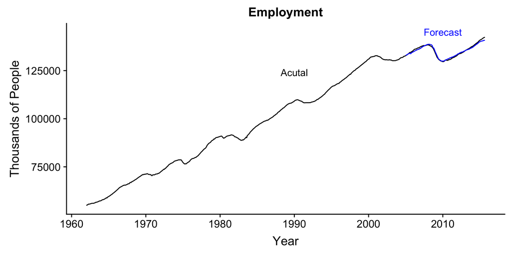

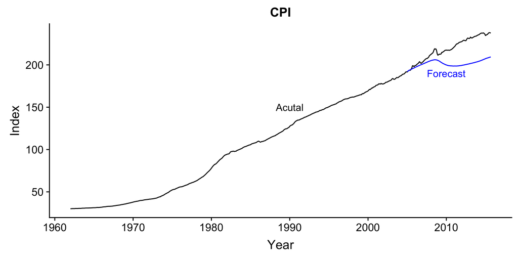

#### 4. Analyze the Forecast Error of the Best Model

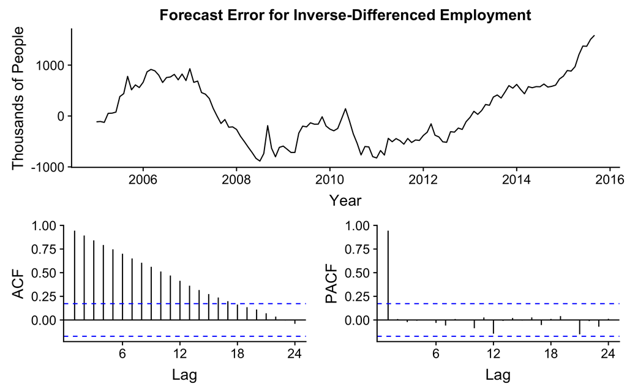

Employment inverse-difference forecast error doesn’t pass the ADF test nor the Ljung-Box test up to 24 lags when critical value=5%. The correlogram suggests an AR(1) effect.

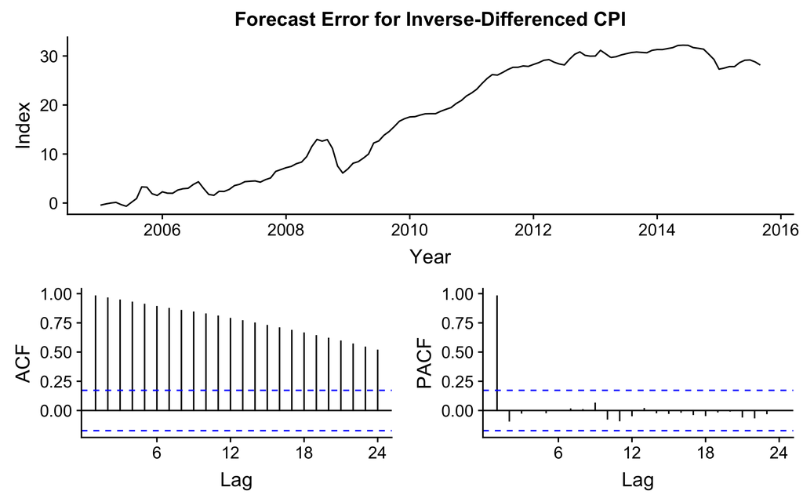

CPI inverse-difference forecast error doesn’t pass the ADF test nor the Ljung-Box test to 24 lags when critical value=5%. The correlogram suggests an AR(1) effect.

Since the best model is selected based on the lowest RMSEs’ sum, employment’s much larger scale overweights employment’s RMSE. So in this best model, employment forecast is much better than CPI forecast. If we use percentage error, both errors can have equal weights.

rmarkdown::render(“U5P4.rmd”)